# Chapter 3: Text Normalisation-Preprocessing

# 1 Table of Content

1. What is Text Normalisation?
2. Lowercasing
3. Remove Punctuation
4. Tokenize
5. Lemmatization
6. Stemming
7. Stopword Removal
8. Remove Numbers
9. Remove the words having length less than 2
10. Challenges

## 1.1 **Learning Outcomes:**

- Explain the concept of normalisation,
- Execute the following preprocessing steps to a dataset using nltk:
  - Lowercase
  - Tokenize
  - Lemmatization
  - Stemming
  - Removing stop words and punctuation
- Differentiate between lemmatization and stemming.

```python
# Import the libraries used in this module
import nltk
nltk.data.path.append("../local_packages/nltk_data")
import pandas as pd
from nltk.stem import PorterStemmer
from nltk.stem import WordNetLemmatizer
from nltk.corpus import stopwords
import string
import re
```

We will load in a data set that will be used to explore text processing techniques.

```python
# Our data is stored in a pickle, a filetype that lets us store python objects
patents = pd.read_pickle('../data/Patent_Dataset.pkl')

# our index is incorrect, quickly reset it
patents = patents.reset_index(drop=True)

patents.head()
```

|  | patent_id | abstract | classifications_cpc | publication_date |
| --- | --- | --- | --- | --- |
| 0 | US06841689-20050111 | There is provided a process for the addition o... | [] | 2005-01-11 |
| 1 | US06895631-20050524 | A buffing pad that includes a substantially co... | [] | 2005-05-24 |
| 2 | US06974769-20051213 | Conductive structures in features of an insula... | [] | 2005-12-13 |
| 3 | US07006202-20060228 | A mask holder for irradiating UV-rays is discl... | [G03B27/42, G03B27/58, G03B27/62] | 2006-02-28 |
| 4 | US07096910-20060829 | A tyre for a vehicle wheel includes a carcass ... | [B29D30/00, B60C9/00, B60C9/02] | 2006-08-29 |

# 2 What is Text Preprocessing?

Pre-processing text means converting it to a more convenient, standard form used for your specific application. It aims to put all text on a level playing field. It requires being aware of what type of text is to be normalized and how it is to be processed afterwards; there is no all-purpose, one size fits all preprocessing procedure.  
To normalise text some key preprocessing steps could be undertaken, for example:

- Lowercasing
- Removing all irrelevant characters (Numbers and Punctuation)
- Removing words that aren’t useful to us - “Stopwords”
- Stemming
- Lemmatization

The above is often referred to as *cleaning* the text. It is also part of an NLP *pipeline*

Typically, the text also undergoes **tokenisation** (segmenting text into words) to aid the normalisation process.

Once through preprocessing your text becomes more predictable and analyzable.

The pre-processing steps undertaken depends on the task. It is not necessary to do any or all of the steps shown below.

There are a range of terminology that are related and used in NLP pre-processing:

- Pre-processing - the broad term for steps to make text ready for analysis
- Text Normalisation - reducing the variance in text by converting similar words to the same word
- Text Cleaning - removing unnecessary parts of text such as irrelevant words or characters

# 3 Lowercasing

Lowercasing all the text data is one of the simplest and most effective forms of text normalisation.

Lowercasing is applicable to some NLP tasks and significantly helps with consistency of the output.

It is useful because in a lot of applications where we are trying to capture meaning, capitalised words have the same meaning as those in lowercase. For example *Cat* (noun) at the beginning of a sentence is referring to the same thing as *cat* in the middle of a sentence.

```python
# Viewing the text before we lowercase it
# using the column "abstract" from the data frame and
# observing the first row in that column (index 0)
patents["abstract"][0]
```

```
'There is provided a process for the addition of a nucleophile across an electron poor carbon-carbon double bond (a Michael addition) comprising contacting in a solvent: i) a nucleophile; ii) a compound comprising an electron poor double bond; and iii) a catalyst comprising a soluble polymer and a p…
```

```python
# lowercase the text using pandas string methods
patents['abstract_lower'] = patents['abstract'].str.lower()
```

```python
# viewing the text after lowercasing
patents["abstract_lower"][0]
```

```
'there is provided a process for the addition of a nucleophile across an electron poor carbon-carbon double bond (a michael addition) comprising contacting in a solvent: i) a nucleophile; ii) a compound comprising an electron poor double bond; and iii) a catalyst comprising a soluble polymer and a p…
```

Warning: lowercasing can be really useful in reducing the difference in words in a text. However, this is not always what we want.

Upper casing text can also be informative to use. For example - if we were looking to extract all “Named Entities” - such as people’s names, locations, products or organisations, then having a capital letter could be really useful!

For example:

*“A turkey may march in Turkey in May or March”*

In the above we will want to treat “Turkey” and “turkey” differently, as well as May/may and March/march.

We decide whether to lowercase based on the task at hand, and whether doing so would help us.

# 4 Remove Punctuation

Punctuation is sometimes irrelevant to the task at hand (such as counting word frequencies). By removing all or certain punctuation we remove the ‘quirks’ of individual sentences, standardising the text.

Python provides a constant called *string.punctuation* that provides a great list of punctuation characters.

We are going to remove the punctuation from our pandas text data. To do this we need to know what the punctuation characters are. We then need a function that will remove punctuation from a string.

```python
# display the standard string punctuation
print(string.punctuation)
```

```
!"#$%&'()*+,-./:;<=>?@[\]^_`{|}~
```

```python
# we need to create a regular expression (covered in the previous chapter)
# which captures all the above punctuation characters
"[{}]".format(string.punctuation)
```

```
'[!"#$%&\'()*+,-./:;<=>?@[\\]^_`{|}~]'
```

```python
# Below is a function that uses regex to remove punctuation from strings
def remove_punct(ptext):
    # replace any punctuation with nothing "", effectively removing it
    ptext = re.sub(string=ptext,
                   pattern="[{}]".format(string.punctuation),
                   repl="")
    return ptext

# by making a function that works for one piece of text
# we can then apply the function to all the pandas text
```

```python
# viewing our text before removing punctuation
patents["abstract"][0]
```

```
'There is provided a process for the addition of a nucleophile across an electron poor carbon-carbon double bond (a Michael addition) comprising contacting in a solvent: i) a nucleophile; ii) a compound comprising an electron poor double bond; and iii) a catalyst comprising a soluble polymer and a p…
```

```python
# apply removing punctuation function to all elements in the column "abstract"
patents['abstract_no_punct'] = patents['abstract'].apply(remove_punct)
```

```python
patents['abstract_no_punct'][0]
```

```
'There is provided a process for the addition of a nucleophile across an electron poor carboncarbon double bond a Michael addition comprising contacting in a solvent i a nucleophile ii a compound comprising an electron poor double bond and iii a catalyst comprising a soluble polymer and a polyamino …
```

We can see above there are no longer punctuation marks. This may make our text not make perfect gramatical sense!

Removing punctuation is one approach to cleaning text. A broader approach is removing non-alphanumeric text. This would cover punctuation, numbers and any other text that is not letters.

We can use basic approaches, like removing all text that isn’t letters. Or we could use more advanced methods that take into account the relationships between words.

For example, if we simply removed all non-alphanumeric text from *“let’s”* we would get *“lets”* which has a different meaning to *“let us”*.

# 5 Tokenize

Tokenization is the process of splitting the given text into smaller pieces called tokens. Words, numbers, punctuation marks and others can be considered as tokens. Tokenization makes it easier to process the text eg find its frequency.

Consider the following text:

*“This is the text given”*

By tokenising the text we receive the following tokens:

*“This”, “is”, “the” “text”, “given”*

In python this often means we go from a text string to a list of strings.

Tokenizers can range in complexity, from using *.split(” “)* on text, to more rule based or machine learning-based implementations. Below we use *nltk*’s word tokenizer.

As some tokenisers can take into account punctuation we do not need to always remove punctuation.

We are going to first look at a basic example of tokenization, then use a more advanced method from *nltk*.

```python
# Basic tokenization example
original_text = "This is the text given"

# Create tokens by splitting the text on each " " space
tokens = original_text.split(" ")

print("Original text:\n\t", original_text)
print("Original text 'type':\n\t", type(original_text).__name__)
print("Tokenized text:\n\t", tokens)
print("Tokenized text 'type':\n\t", type(tokens).__name__)
```

```
Original text:
     This is the text given
Original text 'type':
     str
Tokenized text:
     ['This', 'is', 'the', 'text', 'given']
Tokenized text 'type':
     list
```

```python
# Instead of using split, we can tokenise using functions from nltk,
# other libraries, or create our own
# For our basic text example this will provide the same result
# For more complex/larger text this will be better than splitting
nltk_tokens = nltk.word_tokenize(original_text)
nltk_tokens
```

```
['This', 'is', 'the', 'text', 'given']
```

```python
# text before tokenization
patents["abstract"][0]
```

```
'There is provided a process for the addition of a nucleophile across an electron poor carbon-carbon double bond (a Michael addition) comprising contacting in a solvent: i) a nucleophile; ii) a compound comprising an electron poor double bond; and iii) a catalyst comprising a soluble polymer and a p…
```

```python
# Apply to 'abstract' column in dataframe
patents['abstract_tokens'] = patents['abstract'].apply(nltk.word_tokenize)
```

```python
patents["abstract_tokens"][0]
```

```
['There',
 'is',
 'provided',
 'a',
 'process',
 'for',
 'the',
 'addition',
 'of',
 'a',
 'nucleophile',
 'across',
 'an',
 'electron',
 'poor',
 'carbon-carbon',
 'double',
 'bond',
 '(',
 'a',
 'Michael',
 'addition',
 ')',
 'comprising',
 'contacting',
 'in',
 'a',
 'solvent',
 ':',
 'i',
 ')',
 'a',
 'nucleophile',
 ';',
 'ii',
 ')',
 'a',
 'compound',
 'comprising',
 'an',
 'electron',
 'poor',
 'double',
 'bond',
 ';',
 'and',
 'iii',
 ')',
 'a',
 'catalyst',
 'comprising',
 'a',
 'soluble',
 'polymer',
 'and',
 'a',
 'polyamino',
 'acid',
 '.']
```

Text can also be split to identify sentences.

This can be done using the **sent_tokenize()** function from nltk.

Think about what separates sentences, typically punctuation, this can be used to determine where sentences start and end.

```python
# Apply tokenisation to abstract column in dataframe
patents['abstract_sentences'] = patents['abstract'].apply(nltk.sent_tokenize)
```

```python
# text before sentence segmentation
patents["abstract"][0]
```

```
'There is provided a process for the addition of a nucleophile across an electron poor carbon-carbon double bond (a Michael addition) comprising contacting in a solvent: i) a nucleophile; ii) a compound comprising an electron poor double bond; and iii) a catalyst comprising a soluble polymer and a p…
```

```python
# text after sentence segmentation
patents["abstract_sentences"][0]
```

```
['There is provided a process for the addition of a nucleophile across an electron poor carbon-carbon double bond (a Michael addition) comprising contacting in a solvent: i) a nucleophile; ii) a compound comprising an electron poor double bond; and iii) a catalyst comprising a soluble polymer and a …
```

The above abstract is one long sentence! Let’s look at another abstract to see the result.

```python
patents["abstract_sentences"][1]
```

```
['A buffing pad that includes a substantially conventional buffing pad made of tufted wool that includes a backing plate and a central hub for attachment to the shaft of a rotary power buffer.',
 'The tufts or strands of wool are of a first and substantially equal length and of a substantially uniform color.',
 'The pad also carries a plurality of shorter tufts of wool or other fiber of a contrasting color.',
 'When the pad is relatively new, the shorter tufts are not normally visible as they are hidden by the longer tufts.',
 'As the pad becomes worn, however, the longer tufts become shorter and matted down thereby exposing the shorter tufts.',
 'The appearance of the contrasting color of the shorter tufts is an indicator that the pad is worn and should be replaced.']
```

There we go, each sentence has become it’s own element in a list. After tokenizing the sentences we could then tokenize the individual words within the longer sentence string.

# 6 Stemming

**The process of reducing inflected (or sometimes derived) words to their word stem; that is, their base or root form.**

For example, the words; *argue, argued, argues, arguing* reduce to the stem *argu*.

Usually stemming is a crude heuristic process that chops off the ends of words in the hope of achieving the root correctly most of the time.

Stemming aims to remove the excess part of the word to be able to identify words that are similar.

There are different algorithms that can be used in the stemming process, but the most common in English is **Porter Stemmer.** The rules contained in this algorithm are divided into different phases.The purpose of these rules is to reduce the words to their root.

The danger here lies in the possibility of overstemming where words like “universe” and “university” are reduced to the same root of “univers”.

Below we are going to look at the results of using a stemmer on text. The resulting strings will not necessarily be real words, but they will reduce the diversity of the words in the text. We apply stemming to each word in a text, which means each word needs to be separate from it’s neighbours. This is done using tokenising, so we can take a string of words, break them up, then apply a process to each independently.

```python
# Using the PorterStemmer from nltk
words_to_normalise = "The Ones and twos argues who is winning in todays matches"

# generate tokens
tokens = nltk.word_tokenize(words_to_normalise)

# note we have not applied any other preprocessing to the text
tokens
```

```
['The',
 'Ones',
 'and',
 'twos',
 'argues',
 'who',
 'is',
 'winning',
 'in',
 'todays',
 'matches']
```

```python
# Loop through each token in the list and apply the stemming
tokens_stemmed = [PorterStemmer().stem(token) for token in tokens]

# A list of stemmed words
print(tokens_stemmed)
# The has clearly applied some processing to the text, beyond chopping
# off an ending. This PorterStemmer has also lowercased the text
```

```
['the', 'one', 'and', 'two', 'argu', 'who', 'is', 'win', 'in', 'today', 'match']
```

Throughout this course we are going to follow a similar code structure to the bellow:

- write a function that performs what we want on a single piece of data (such as a string, or list depending on context)
- apply this function to every row in the data set

There are often ways we can use pandas itself to do string manipulation which may be more efficient than creating a custom function, but for some data structures like lists to deal with the pandas solution is harder to understand.

```python
## Applying stemming to the pandas data
# Define stemming function

def stemming(ptoken):
    # create stemming object
    stemmer = PorterStemmer()
    return [stemmer.stem(token) for token in ptoken]
```

```python
# tokens pre-stemming
patents['abstract_tokens'][0]
```

```
['There',
 'is',
 'provided',
 'a',
 'process',
 'for',
 'the',
 'addition',
 'of',
 'a',
 'nucleophile',
 'across',
 'an',
 'electron',
 'poor',
 'carbon-carbon',
 'double',
 'bond',
 '(',
 'a',
 'Michael',
 'addition',
 ')',
 'comprising',
 'contacting',
 'in',
 'a',
 'solvent',
 ':',
 'i',
 ')',
 'a',
 'nucleophile',
 ';',
 'ii',
 ')',
 'a',
 'compound',
 'comprising',
 'an',
 'electron',
 'poor',
 'double',
 'bond',
 ';',
 'and',
 'iii',
 ')',
 'a',
 'catalyst',
 'comprising',
 'a',
 'soluble',
 'polymer',
 'and',
 'a',
 'polyamino',
 'acid',
 '.']
```

```python
patents['abstract_tokens_stemmed'] = patents['abstract_tokens'].apply(stemming)
```

```python
# tokens post stemming
patents['abstract_tokens_stemmed'][0]
```

```
['there',
 'is',
 'provid',
 'a',
 'process',
 'for',
 'the',
 'addit',
 'of',
 'a',
 'nucleophil',
 'across',
 'an',
 'electron',
 'poor',
 'carbon-carbon',
 'doubl',
 'bond',
 '(',
 'a',
 'michael',
 'addit',
 ')',
 'compris',
 'contact',
 'in',
 'a',
 'solvent',
 ':',
 'i',
 ')',
 'a',
 'nucleophil',
 ';',
 'ii',
 ')',
 'a',
 'compound',
 'compris',
 'an',
 'electron',
 'poor',
 'doubl',
 'bond',
 ';',
 'and',
 'iii',
 ')',
 'a',
 'catalyst',
 'compris',
 'a',
 'solubl',
 'polym',
 'and',
 'a',
 'polyamino',
 'acid',
 '.']
```

```python
# comparing the pre and post stemmed tokens
list(zip(patents['abstract_tokens'][0], patents['abstract_tokens_stemmed'][0]))
```

```
[('There', 'there'),
 ('is', 'is'),
 ('provided', 'provid'),
 ('a', 'a'),
 ('process', 'process'),
 ('for', 'for'),
 ('the', 'the'),
 ('addition', 'addit'),
 ('of', 'of'),
 ('a', 'a'),
 ('nucleophile', 'nucleophil'),
 ('across', 'across'),
 ('an', 'an'),
 ('electron', 'electron'),
 ('poor', 'poor'),
 ('carbon-carbon', 'carbon-carbon'),
 ('double', 'doubl'),
 ('bond', 'bond'),
 ('(', '('),
 ('a', 'a'),
 ('Michael', 'michael'),
 ('addition', 'addit'),
 (')', ')'),
 ('comprising', 'compris'),
 ('contacting', 'contact'),
 ('in', 'in'),
 ('a', 'a'),
 ('solvent', 'solvent'),
 (':', ':'),
 ('i', 'i'),
 (')', ')'),
 ('a', 'a'),
 ('nucleophile', 'nucleophil'),
 (';', ';'),
 ('ii', 'ii'),
 (')', ')'),
 ('a', 'a'),
 ('compound', 'compound'),
 ('comprising', 'compris'),
 ('an', 'an'),
 ('electron', 'electron'),
 ('poor', 'poor'),
 ('double', 'doubl'),
 ('bond', 'bond'),
 (';', ';'),
 ('and', 'and'),
 ('iii', 'iii'),
 (')', ')'),
 ('a', 'a'),
 ('catalyst', 'catalyst'),
 ('comprising', 'compris'),
 ('a', 'a'),
 ('soluble', 'solubl'),
 ('polymer', 'polym'),
 ('and', 'and'),
 ('a', 'a'),
 ('polyamino', 'polyamino'),
 ('acid', 'acid'),
 ('.', '.')]
```

Looking at those results we can see that the number of different tokens will reduce in a big corpus. However, this does make some of the resulting tokens less informative. There’s a tradeoff here between how understandable our resulting words are, and how much we reduce the diversity.

# 7 Lemmatization

Lemmatisation uses vocabulary and morphological analysis of words to remove inflectional endings only and to return the base or dictionary form of a word, which is known as the **lemma.** Most lemmatisers achieve this using a lookup table and so this process, when you have large volumes of text may be slower than the alternative; stemming. However, it is often a recommended approach in a variety of applications due to it’s accuracy.

Also, sometimes, the same word can have multiple different ‘lemma’s. So, based on the context it’s used in, you should identify the ‘part-of-speech’ (POS) tag for the word in that specific context and extract the appropriate lemma. POS tagging will be discussed in more detail in later modules.

A part of speech refers to the type of a word. For example we can have nouns, verb, adjectives and so on to describe a word. We can however go into much more depth to describe what a word part of speech is by introducing more and more types. Below a basic example is shown. When we know what part of speech a word is we can better lemmatize it.

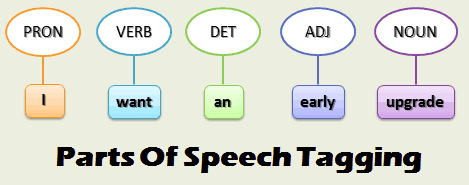

The WordNet lemmatizer shown below is a “lexical” lemmatizer. It contains a wide range of words, their lemmas and when called takes whatever word is given, and returns the lemma if it has an entry for it. If it doesn’t have an entry it will just return the origin word.

Bewlow we are going to follow a similar set of steps to the stemming above. We will analyse the effect of lemmatising on our toy example, then on the pandas patents data set.

```python
# Using the WordNetLemmatizer from nltk
# without using the parts of speech tagging it doesn't perform incredibly well
# But it does always result in valid words where it runs

# Run tokenizer
tokens = nltk.word_tokenize(words_to_normalise)
print(words_to_normalise)
tokens
```

```
The Ones and twos argues who is winning in todays matches
```

```
['The',
 'Ones',
 'and',
 'twos',
 'argues',
 'who',
 'is',
 'winning',
 'in',
 'todays',
 'matches']
```

```python
tokens_lemmed = [WordNetLemmatizer().lemmatize(token) for token in tokens]
print(tokens_lemmed)
type(tokens_lemmed)
```

```
['The', 'Ones', 'and', 'two', 'argues', 'who', 'is', 'winning', 'in', 'today', 'match']
```

```
list
```

Compared to the stemmer we have more words that have been missed / not touched. However, “todays” -> “today”, “matches” -> “match” and so on, which are good normalisations. The words that have been lemmatized are now actual words, in comparison with the stemming method.

```python
# Define the lemmatize() function

def lemmatise(ptokens):
    lemmatizer = WordNetLemmatizer()
    return [lemmatizer.lemmatize(token) for token in ptokens]
```

```python
# tokens before lemmatization
patents["abstract_tokens"][0]
```

```
['There',
 'is',
 'provided',
 'a',
 'process',
 'for',
 'the',
 'addition',
 'of',
 'a',
 'nucleophile',
 'across',
 'an',
 'electron',
 'poor',
 'carbon-carbon',
 'double',
 'bond',
 '(',
 'a',
 'Michael',
 'addition',
 ')',
 'comprising',
 'contacting',
 'in',
 'a',
 'solvent',
 ':',
 'i',
 ')',
 'a',
 'nucleophile',
 ';',
 'ii',
 ')',
 'a',
 'compound',
 'comprising',
 'an',
 'electron',
 'poor',
 'double',
 'bond',
 ';',
 'and',
 'iii',
 ')',
 'a',
 'catalyst',
 'comprising',
 'a',
 'soluble',
 'polymer',
 'and',
 'a',
 'polyamino',
 'acid',
 '.']
```

```python
# apply lemmatisation to all tokens in column
patents['abstract_tokens_lemmatised'] = patents['abstract_tokens'].apply(lemmatise)
```

```python
# tokens after lemmatization
patents["abstract_tokens_lemmatised"][0]
```

```
['There',
 'is',
 'provided',
 'a',
 'process',
 'for',
 'the',
 'addition',
 'of',
 'a',
 'nucleophile',
 'across',
 'an',
 'electron',
 'poor',
 'carbon-carbon',
 'double',
 'bond',
 '(',
 'a',
 'Michael',
 'addition',
 ')',
 'comprising',
 'contacting',
 'in',
 'a',
 'solvent',
 ':',
 'i',
 ')',
 'a',
 'nucleophile',
 ';',
 'ii',
 ')',
 'a',
 'compound',
 'comprising',
 'an',
 'electron',
 'poor',
 'double',
 'bond',
 ';',
 'and',
 'iii',
 ')',
 'a',
 'catalyst',
 'comprising',
 'a',
 'soluble',
 'polymer',
 'and',
 'a',
 'polyamino',
 'acid',
 '.']
```

```python
# Comparison of normalisation
list(zip(patents["abstract_tokens"][0], patents["abstract_tokens_lemmatised"][0]))
```

```
[('There', 'There'),
 ('is', 'is'),
 ('provided', 'provided'),
 ('a', 'a'),
 ('process', 'process'),
 ('for', 'for'),
 ('the', 'the'),
 ('addition', 'addition'),
 ('of', 'of'),
 ('a', 'a'),
 ('nucleophile', 'nucleophile'),
 ('across', 'across'),
 ('an', 'an'),
 ('electron', 'electron'),
 ('poor', 'poor'),
 ('carbon-carbon', 'carbon-carbon'),
 ('double', 'double'),
 ('bond', 'bond'),
 ('(', '('),
 ('a', 'a'),
 ('Michael', 'Michael'),
 ('addition', 'addition'),
 (')', ')'),
 ('comprising', 'comprising'),
 ('contacting', 'contacting'),
 ('in', 'in'),
 ('a', 'a'),
 ('solvent', 'solvent'),
 (':', ':'),
 ('i', 'i'),
 (')', ')'),
 ('a', 'a'),
 ('nucleophile', 'nucleophile'),
 (';', ';'),
 ('ii', 'ii'),
 (')', ')'),
 ('a', 'a'),
 ('compound', 'compound'),
 ('comprising', 'comprising'),
 ('an', 'an'),
 ('electron', 'electron'),
 ('poor', 'poor'),
 ('double', 'double'),
 ('bond', 'bond'),
 (';', ';'),
 ('and', 'and'),
 ('iii', 'iii'),
 (')', ')'),
 ('a', 'a'),
 ('catalyst', 'catalyst'),
 ('comprising', 'comprising'),
 ('a', 'a'),
 ('soluble', 'soluble'),
 ('polymer', 'polymer'),
 ('and', 'and'),
 ('a', 'a'),
 ('polyamino', 'polyamino'),
 ('acid', 'acid'),
 ('.', '.')]
```

Caring -> Lemmatization -> ‘Care’  
Caring -> Stemming -> ‘Car’

**Example:**

*“better”*: has *“good”* as its lemma and “better” as its stem  
*“walking”*: has *“walk”* as its lemma and stem  
*“meeting”*: can be either the base a noun or a verb depending on the context, eg *“in our last meeting”* or *“We are meeting again tomorrow”*.  
Lemmatization can select the appropriate lemma based on the context, unlike stemming.

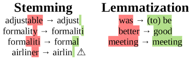

Stemming is often a faster process, but less accurate / useful. So the specific use case is important in deciding which method to choose.

# 8 Stopword Removal

A stop word is a commonly used word (such as “the”, “a”, “an”, “in”). Stop words can be filtered from the text to be processed. There is no universal list of stop words in NLP, however the nltk module contains a list of stop words. Removal of stopwords can boost performance in machine learning classification tasks.

Stop word removal is commonly applied in search systems, text classification applications, topic modeling, topic extraction and others. Stop word lists can come from pre-established sets or you can create a custom one for your domain.

Often we will need to select out own stopwords for a task, because not all text is the same and all language can be different. What is “unimportant” in one analysis/application may be crucial in another.

The reason this often works is because stopwords often do not add meaning to the sentence. For example if you wanted to work out what was important in the sentence below:

“The cat ate a mouse”

The same sentence without stopwords conveys most of the meaning:

“cat ate mouse”

Below we are going to work through an example of removing stopwords from a text.

```python
# Display the basic stopwords given by nltk
print(stopwords.words('english'))
```

```
['i', 'me', 'my', 'myself', 'we', 'our', 'ours', 'ourselves', 'you', "you're", "you've", "you'll", "you'd", 'your', 'yours', 'yourself', 'yourselves', 'he', 'him', 'his', 'himself', 'she', "she's", 'her', 'hers', 'herself', 'it', "it's", 'its', 'itself', 'they', 'them', 'their', 'theirs', 'themselve…
```

```python
# you can set the language for stopwords
# We have used a set() below, which is a data structure
# that is useful for checking if some data is present somewhere else efficiently
# (checking membership)
stop_words_french = set(stopwords.words('french'))
print(stop_words_french)
```

```
{'vous', 'que', 'étante', 'avec', 'ait', 'as', 'aies', 'étais', 'seraient', 'même', 'étiez', 'notre', 'seriez', 'eûmes', 'des', 'aurai', 'dans', 'aura', 'eut', 'ou', 'mes', 'aie', 'serais', 'ayante', 'eussions', 'n', 'ces', 'fusse', 'ta', 'je', 'fut', 'le', 'un', 'sera', 'seront', 'soyons', 'avaient…
```

```python
del stop_words_french
# let's ensure we are using English stopwords for this project
stop_words = set(stopwords.words('english'))
```

**Note:** the default stopwords from *nltk* while useful, were created using domain knowledge and algorithms, rather than using a statistical method alone. Stopword collections are best custom made and specific for an individual application. The information on how it was curated is patchy at best. It was created for the [Snowball project](https://snowballstem.org/projects.html).

```python
# Define a function to remove stopwords from list of tokens
def clean_stopwords(tokens):
    # define stopwords
    stop_words = set(stopwords.words('english'))
    # loop through each token and if the word isn't in the set
    # of stopwords keep it
    return [item for item in tokens if item not in stop_words]
```

```python
# Pre stopword removal
patents['abstract_tokens'][0]
```

```
['There',
 'is',
 'provided',
 'a',
 'process',
 'for',
 'the',
 'addition',
 'of',
 'a',
 'nucleophile',
 'across',
 'an',
 'electron',
 'poor',
 'carbon-carbon',
 'double',
 'bond',
 '(',
 'a',
 'Michael',
 'addition',
 ')',
 'comprising',
 'contacting',
 'in',
 'a',
 'solvent',
 ':',
 'i',
 ')',
 'a',
 'nucleophile',
 ';',
 'ii',
 ')',
 'a',
 'compound',
 'comprising',
 'an',
 'electron',
 'poor',
 'double',
 'bond',
 ';',
 'and',
 'iii',
 ')',
 'a',
 'catalyst',
 'comprising',
 'a',
 'soluble',
 'polymer',
 'and',
 'a',
 'polyamino',
 'acid',
 '.']
```

```python
patents['tokens_no_stops'] = patents['abstract_tokens'].apply(clean_stopwords)
```

```python
# Post stopword removal
patents['tokens_no_stops'][0]
```

```
['There',
 'provided',
 'process',
 'addition',
 'nucleophile',
 'across',
 'electron',
 'poor',
 'carbon-carbon',
 'double',
 'bond',
 '(',
 'Michael',
 'addition',
 ')',
 'comprising',
 'contacting',
 'solvent',
 ':',
 ')',
 'nucleophile',
 ';',
 'ii',
 ')',
 'compound',
 'comprising',
 'electron',
 'poor',
 'double',
 'bond',
 ';',
 'iii',
 ')',
 'catalyst',
 'comprising',
 'soluble',
 'polymer',
 'polyamino',
 'acid',
 '.']
```

```python
# These were the stopwords that were removed
found_stopwords = []

# go through each unique token
for token in set(patents['abstract_tokens'][0]):
    if token in stop_words:
        found_stopwords.append(token)

found_stopwords
```

```
['is', 'the', 'of', 'a', 'in', 'for', 'and', 'an', 'i']
```